# Datos electorales

# 1 - Leemos los datos

Datos electorales para la tercera seccion electoral en la elección 2019.

```r
datos <- read.csv("https://raw.githubusercontent.com/LeanColisko/elecciones_2019/main/datos/elecciones_2019_datos_tercera_seccion.csv", fileEncoding = "UTF-8")

head(datos)
```

|  | PROVINCIA | SECCION | Circuito | NOMBRE_CATEGORIA | NOMBRE_AGRUPACION | PASO | GRAL |
| --- | --- | --- | --- | --- | --- | --- | --- |
| 1 | Buenos Aires | Almirante Brown | 0017 | Presidente y Vicepresidente de la República | CONSENSO FEDERAL | 1769 | 1301 |
| 2 | Buenos Aires | Almirante Brown | 0017 | Presidente y Vicepresidente de la República | CSCCC | 11 | 14 |
| 3 | Buenos Aires | Almirante Brown | 0017 | Presidente y Vicepresidente de la República | FRENTE DE IZQUIERDA Y DE TRABAJADORES - UNIDAD | 681 | 546 |
| 4 | Buenos Aires | Almirante Brown | 0017 | Presidente y Vicepresidente de la República | FRENTE DE TODOS | 4917 | 5593 |
| 5 | Buenos Aires | Almirante Brown | 0017 | Presidente y Vicepresidente de la República | FRENTE NOS | 217 | 119 |
| 6 | Buenos Aires | Almirante Brown | 0017 | Presidente y Vicepresidente de la República | JUNTOS POR EL CAMBIO | 8792 | 10995 |

# 2 - Funciones exploratorias

Aplicamos funciones exploratorias para conocer un poco más de nuestra estructura de datos.

Nombre de columnas

```r
names(datos)
```

```
[1] "PROVINCIA"         "SECCION"           "Circuito"
[4] "NOMBRE_CATEGORIA"  "NOMBRE_AGRUPACION" "PASO"
[7] "GRAL"
```

Estructura de datos

```r
str(datos)
```

```
'data.frame':   2767 obs. of  7 variables:
 $ PROVINCIA        : chr  "Buenos Aires" "Buenos Aires" "Buenos Aires" "Buenos Aires" ...
 $ SECCION          : chr  "Almirante Brown" "Almirante Brown" "Almirante Brown" "Almirante Brown" ...
 $ Circuito         : chr  "0017" "0017" "0017" "0017" ...
 $ NOMBRE_CATEGORIA : chr  "Presidente y Vicepresidente de la República" "Presidente y Vicepresidente de la República" "Presidente y Vicepresidente de la República" "Presidente y Vicepresidente de la República" ...
 $ NOMBRE_AGRUPACION: chr  "CONSENSO FEDERAL" "CSCCC" "FRENTE DE IZQUIERDA Y DE TRABAJADORES - UNIDAD" "FRENTE DE TODOS" ...
 $ PASO             : int  1769 11 681 4917 217 8792 525 441 6 125 ...
 $ GRAL             : int  1301 14 546 5593 119 10995 319 213 5 147 ...
```

Resumen de las variables

```r
summary(datos)
```

```
  PROVINCIA           SECCION            Circuito
 Length:2767        Length:2767        Length:2767
 Class :character   Class :character   Class :character
 Mode  :character   Mode  :character   Mode  :character



 NOMBRE_CATEGORIA   NOMBRE_AGRUPACION       PASO
 Length:2767        Length:2767        Min.   :    0.0
 Class :character   Class :character   1st Qu.:    7.0
 Mode  :character   Mode  :character   Median :   65.0
                                       Mean   : 1187.2
                                       3rd Qu.:  484.5
                                       Max.   :95339.0
      GRAL
 Min.   :     0.0
 1st Qu.:     0.0
 Median :    19.0
 Mean   :  1249.3
 3rd Qu.:   395.5
 Max.   :103499.0
```

Primeras 6 lineas de datos

```r
head(datos)
```

|  | PROVINCIA | SECCION | Circuito | NOMBRE_CATEGORIA | NOMBRE_AGRUPACION | PASO | GRAL |
| --- | --- | --- | --- | --- | --- | --- | --- |
| 1 | Buenos Aires | Almirante Brown | 0017 | Presidente y Vicepresidente de la República | CONSENSO FEDERAL | 1769 | 1301 |
| 2 | Buenos Aires | Almirante Brown | 0017 | Presidente y Vicepresidente de la República | CSCCC | 11 | 14 |
| 3 | Buenos Aires | Almirante Brown | 0017 | Presidente y Vicepresidente de la República | FRENTE DE IZQUIERDA Y DE TRABAJADORES - UNIDAD | 681 | 546 |
| 4 | Buenos Aires | Almirante Brown | 0017 | Presidente y Vicepresidente de la República | FRENTE DE TODOS | 4917 | 5593 |
| 5 | Buenos Aires | Almirante Brown | 0017 | Presidente y Vicepresidente de la República | FRENTE NOS | 217 | 119 |
| 6 | Buenos Aires | Almirante Brown | 0017 | Presidente y Vicepresidente de la República | JUNTOS POR EL CAMBIO | 8792 | 10995 |

Últimas 6 lineas de datos

```r
tail(datos)
```

|  | PROVINCIA | SECCION | Circuito | NOMBRE_CATEGORIA | NOMBRE_AGRUPACION | PASO | GRAL |
| --- | --- | --- | --- | --- | --- | --- | --- |
| 2762 | Buenos Aires | Ezeiza | 0290A | Presidente y Vicepresidente de la República | MOVIMIENTO DE ACCION VECINAL | 31 | 0 |
| 2763 | Buenos Aires | Ezeiza | 0290A | Presidente y Vicepresidente de la República | PARTIDO AUTONOMISTA | 23 | 0 |
| 2764 | Buenos Aires | Ezeiza | 0290B | Presidente y Vicepresidente de la República | FRENTE PATRIOTA | 29 | 0 |
| 2765 | Buenos Aires | Ezeiza | 0290B | Presidente y Vicepresidente de la República | MOVIMIENTO AL SOCIALISMO | 74 | 0 |
| 2766 | Buenos Aires | Ezeiza | 0290B | Presidente y Vicepresidente de la República | MOVIMIENTO DE ACCION VECINAL | 18 | 0 |
| 2767 | Buenos Aires | Ezeiza | 0290B | Presidente y Vicepresidente de la República | PARTIDO AUTONOMISTA | 11 | 0 |

# 3 - Modificamos los datos

Hay dos columnas que no nos hacen falta: PROVINCIA y CATEGORÍA Los valores de estas columnas son siempre los mismos y son previamente conocidos por los filtros que aplicamos. Por lo tanto vamos a eliminar estas dos columnas.

Como vamos a trabajar con dplyr: primero activamos la librería

```r
# Activamos la librería
library(dplyr)
#Eliminamos las columnas que no necesitamos
datos_clean <- datos %>%
  select(-c(PROVINCIA, NOMBRE_CATEGORIA))
```

Ahora tenemos 5 variables:

- Sección
- Circuito
- NOMBRE_AGRUPACION
- PASO
- GRAL

# 4 - Resultados por agrupación

Con los datos limpios vamos a ver la suma de votos de cada agrupación.

```r
datos_clean %>%
  group_by(NOMBRE_AGRUPACION) %>%
  summarise(PASO_x_AGRUP = sum(PASO),
            GRAL_x_AGRUP = sum(GRAL)) %>%
  mutate(`% PASO` = PASO_x_AGRUP / sum(PASO_x_AGRUP) * 100,
         `% GRAL` = GRAL_x_AGRUP / sum(GRAL_x_AGRUP) * 100)
```

| NOMBRE_AGRUPACION | PASO_x_AGRUP | GRAL_x_AGRUP | % PASO | % GRAL |
| --- | --- | --- | --- | --- |
| CONSENSO FEDERAL | 240080 | 212654 | 7.30834246 | 6.15154709 |
| CSCCC | 2505 | 2094 | 0.07625541 | 0.06057417 |
| FRENTE DE IZQUIERDA Y DE TRABAJADORES - UNIDAD | 120122 | 97764 | 3.65666742 | 2.82806742 |
| FRENTE DE TODOS | 1893107 | 2015563 | 57.62859995 | 58.30518447 |
| FRENTE NOS | 52030 | 50993 | 1.58385979 | 1.47509965 |
| FRENTE PATRIOTA | 8706 | 0 | 0.26502178 | 0.00000000 |
| JUNTOS POR EL CAMBIO | 762104 | 955878 | 23.19942113 | 27.65115411 |
| MOVIMIENTO AL SOCIALISMO | 25706 | 0 | 0.78252354 | 0.00000000 |
| MOVIMIENTO DE ACCION VECINAL | 2828 | 0 | 0.08608794 | 0.00000000 |
| PARTIDO AUTONOMISTA | 2991 | 0 | 0.09104987 | 0.00000000 |

[output cut: 5 more lines]

Como ejemplo mostramos los resultados para Avellaneda.

```r
datos_clean %>%
  filter(SECCION == 'Avellaneda') %>%
  group_by(NOMBRE_AGRUPACION) %>%
  summarise(PASO_x_AGRUP = sum(PASO),
            GRAL_x_AGRUP = sum(GRAL)) %>%
  mutate(`% PASO` = PASO_x_AGRUP / sum(PASO_x_AGRUP) * 100,
         `% GRAL` = GRAL_x_AGRUP / sum(GRAL_x_AGRUP) * 100)
```

| NOMBRE_AGRUPACION | PASO_x_AGRUP | GRAL_x_AGRUP | % PASO | % GRAL |
| --- | --- | --- | --- | --- |
| CONSENSO FEDERAL | 17300 | 13864 | 7.95416927 | 6.18373691 |
| CSCCC | 260 | 173 | 0.11954243 | 0.07716290 |
| FRENTE DE IZQUIERDA Y DE TRABAJADORES - UNIDAD | 7918 | 6120 | 3.64052672 | 2.72969344 |
| FRENTE DE TODOS | 115765 | 121552 | 53.22626623 | 54.21563686 |
| FRENTE NOS | 2559 | 2426 | 1.17657336 | 1.08206475 |
| FRENTE PATRIOTA | 603 | 0 | 0.27724648 | 0.00000000 |
| JUNTOS POR EL CAMBIO | 59884 | 72553 | 27.53337992 | 32.36069420 |
| MOVIMIENTO AL SOCIALISMO | 1934 | 0 | 0.88921176 | 0.00000000 |
| MOVIMIENTO DE ACCION VECINAL | 14 | 0 | 0.00643690 | 0.00000000 |
| PARTIDO AUTONOMISTA | 199 | 0 | 0.09149594 | 0.00000000 |

[output cut: 5 more lines]

Datos para todas las secciones. Lo guardamos en un nuevo objeto. Creamos nuevas variables para cada sección, vemos la cantidad de votos que sacaron cada agrupación. Además agregamos el porcentaje de votos que sacó cada agrupación en cada una de las secciones, para la elección PASO y GENERAL. Finalmente agregamos una variable que indique la posición que ocupó cada agrupación en la elección general. De esta manera podemos ver quien ganó en la sección.

```r
resultados <- datos_clean %>%
  group_by(SECCION, NOMBRE_AGRUPACION) %>%
  summarise(PASO_x_AGRUP = sum(PASO),
            GRAL_x_AGRUP = sum(GRAL)) %>%
  mutate(`% PASO` = PASO_x_AGRUP / sum(PASO_x_AGRUP) * 100,
         `% GRAL` = GRAL_x_AGRUP / sum(GRAL_x_AGRUP) * 100) %>%
  arrange(SECCION, desc(`% GRAL`)) %>%
  mutate(Puestos_GRAL = row_number()) %>%
  arrange(SECCION, desc(`% PASO`)) %>%
  mutate(Puestos_PASO = row_number())
```

Mostramos los resultados de quienes salieron primeros en la elección GENERAL.

```r
resultados %>%
  filter(Puestos_GRAL==1)
```

| SECCION | NOMBRE_AGRUPACION | PASO_x_AGRUP | GRAL_x_AGRUP | % PASO | % GRAL | Puestos_GRAL | Puestos_PASO |
| --- | --- | --- | --- | --- | --- | --- | --- |
| Almirante Brown | FRENTE DE TODOS | 192758 | 206155 | 58.27025 | 58.83570 | 1 | 1 |
| Avellaneda | FRENTE DE TODOS | 115765 | 121552 | 53.22627 | 54.21564 | 1 | 1 |
| Berazategui | FRENTE DE TODOS | 113890 | 119648 | 56.86652 | 57.72511 | 1 | 1 |
| Berisso | FRENTE DE TODOS | 31480 | 34873 | 54.45236 | 54.24918 | 1 | 1 |
| Brandsen | FRENTE DE TODOS | 9178 | 9217 | 49.19333 | 47.43695 | 1 | 1 |
| Cañuelas | FRENTE DE TODOS | 17239 | 18018 | 51.88251 | 52.10978 | 1 | 1 |
| Ensenada | FRENTE DE TODOS | 24348 | 25990 | 59.93206 | 59.95663 | 1 | 1 |
| Esteban Echeverría | FRENTE DE TODOS | 95926 | 101565 | 56.14436 | 56.87526 | 1 | 1 |
| Ezeiza | FRENTE DE TODOS | 54998 | 59943 | 58.09259 | 58.90741 | 1 | 1 |
| Florencio Varela | FRENTE DE TODOS | 151594 | 164339 | 65.46329 | 66.26653 | 1 | 1 |

[output cut: 9 more lines]

# 5 - Modificar la estructura de los datos

Queremos construir una tabla con los datosa nivel de circuito. Cada fila representa un circuito y los circuitos no están duplicados Esto lo podemos hacer pivoteando con las funciones de tidyr. En particular con las funciones de pivoteo de datos *pivot_wider* y *pivot_longer*.

```r
library(tidyr)

datos_circuito <- datos_clean %>%
  pivot_wider(id_cols = c(SECCION, Circuito),
              names_from = NOMBRE_AGRUPACION,
              names_sep = " ; ",
              values_from = c(PASO, GRAL))
```

Ahora vamos a hacer una tabla que para cada circuito nos diga quien ganó la elección PASO y General. Esto después podemos visualizarlo en un mapa.

```r
ganadores_gral <- datos_clean %>%
  filter(GRAL != 0) %>%
  group_by(SECCION, Circuito) %>%
  arrange(Circuito, desc(GRAL)) %>%
  mutate(POSICION_GRALES = row_number()) %>%
  ungroup() %>%
  filter(POSICION_GRALES == 1) %>%
  select(SECCION, Circuito, NOMBRE_AGRUPACION) %>%
  rename(GANADOR_GENERAL = NOMBRE_AGRUPACION)

ganadores_paso <- datos_clean %>%
  filter(PASO != 0) %>%
  group_by(SECCION, Circuito) %>%
  arrange(Circuito, desc(PASO)) %>%
  mutate(POSICION_PASO = row_number()) %>%
  ungroup() %>%
  filter(POSICION_PASO == 1) %>%
  select(SECCION, Circuito, NOMBRE_AGRUPACION) %>%
  rename(GANADOR_PASO = NOMBRE_AGRUPACION)

ganadores <- ganadores_gral %>%
  left_join(ganadores_paso)
head(ganadores)
```

| SECCION | Circuito | GANADOR_GENERAL | GANADOR_PASO |
| --- | --- | --- | --- |
| Almirante Brown | 0017 | JUNTOS POR EL CAMBIO | JUNTOS POR EL CAMBIO |
| Almirante Brown | 0018 | FRENTE DE TODOS | FRENTE DE TODOS |
| Almirante Brown | 0018A | FRENTE DE TODOS | FRENTE DE TODOS |
| Almirante Brown | 0019 | FRENTE DE TODOS | FRENTE DE TODOS |
| Almirante Brown | 0020 | FRENTE DE TODOS | FRENTE DE TODOS |
| Almirante Brown | 0020A | FRENTE DE TODOS | FRENTE DE TODOS |

# 6 - Lectura de datos geográficos

```r
library(sf)
# Datos del circuito electoral
circuitos <- read_sf("https://github.com/LeanColisko/elecciones_2019/raw/main/datos/circuitos_BsAs.geojson")
head(circuitos)
```

```
Simple feature collection with 6 features and 9 fields
geometry type:  MULTIPOLYGON
dimension:      XY
bbox:           xmin: -60.99013 ymin: -37.11977 xmax: -58.01254 ymax: -33.85625
geographic CRS: WGS 84
```

| id | gid | distrito | provincia | departamen | cabecera | circuito | indec_p | indec_d | geometry |
| --- | --- | --- | --- | --- | --- | --- | --- | --- | --- |
| circuito_02.fid-421fea78_17c9425fece_6cf | 18713 | 02 | Buenos Aires | La Plata | La Plata | 0508B | 06 | 441 |  |
| circuito_02.fid-421fea78_17c9425fece_6d0 | 17888 | 02 | Buenos Aires | Colón | Colón | 0231A | 06 | 175 |  |
| circuito_02.fid-421fea78_17c9425fece_6d1 | 17696 | 02 | Buenos Aires | Almirante Brown | Almirante Brown | 0018 | 06 | 028 |  |
| circuito_02.fid-421fea78_17c9425fece_6d2 | 17740 | 02 | Buenos Aires | La Matanza | La Matanza | 0635E | 06 | 427 |  |
| circuito_02.fid-421fea78_17c9425fece_6d3 | 17773 | 02 | Buenos Aires | Azul | Azul | 0063 | 06 | 049 |  |
| circuito_02.fid-421fea78_17c9425fece_6d4 | 17847 | 02 | Buenos Aires | Cañuelas | Cañuelas | 0159 | 06 | 133 |  |

Con la biblioteca ggplot hacemos un gráfico con los datos que cargamos. Como vemos, encontramos un mapa de la provincia de Buenos Aires, donde cada poligono es un circuito electoral. Nuestra tarea es utilizar esta información y completarla con los resultados electorales para visualizar en forma rápida los ganadores por cada uno de los circuitos elecorales.

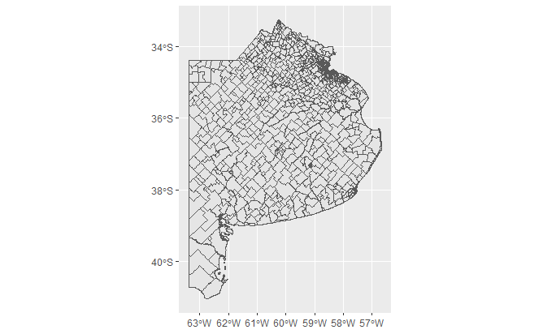

```r
library(ggplot2)

ggplot(data = circuitos) +
  geom_sf()
```

# 7 - Unión de datos geográficos y electorales

Unimos los datos de los resultados electorales de cada circuito con los datos geográficos.

```r
circuitos <- circuitos %>%
  left_join(ganadores, by = c("circuito"="Circuito")) %>%
  filter(!is.na(SECCION))
```

# 8 - Graficamos los resultados en un mapa

Teniendo los datos unificados, ahora con ayuda de *ggplot* podemos hace nuestros mapas temáticos. Vamos a ver que agrupación ganó en cada uno de los circuitos electorales en las elecciones PASO y luego vamos a hacer lo mismo con las elecciones generales.

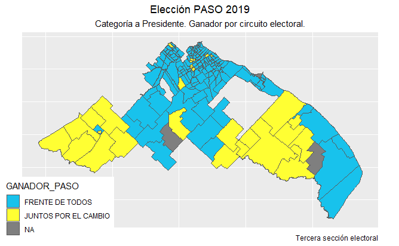

```r
## Graficamos los datos de los ganadores de la eleccion PASO
ggplot(data = circuitos, aes(fill = GANADOR_PASO)) +
  geom_sf() +
  scale_fill_manual(values = c("#18C2EC", "#FFFF33")) +
  labs(title = "Elección PASO 2019",
       subtitle = "Categoría a Presidente. Ganador por circuito electoral.",
       caption = "Tercera sección electoral") +
  theme(legend.position = c(0.1, 0.1),
        axis.text = element_blank(),
        axis.ticks = element_blank(),
        plot.background = element_blank(),
        plot.title = element_text(hjust = 0.5),
        plot.subtitle = element_text(hjust = 0.5))
```

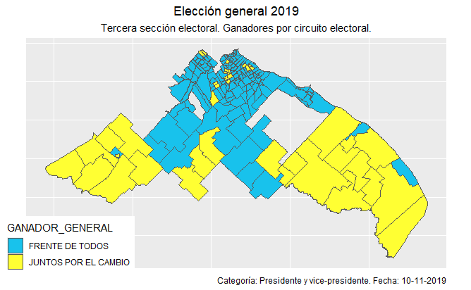

```r
## Graficamos los datos de los ganadores de la eleccion GRAL
ggplot(data = circuitos, aes(fill = GANADOR_GENERAL)) +
  geom_sf() +
  scale_fill_manual(values = c("#18C2EC", "#FFFF33")) +
  labs(title = "Elección general 2019",
       subtitle = "Tercera sección electoral. Ganadores por circuito electoral.",
       caption = "Categoría: Presidente y vice-presidente. Fecha: 10-11-2019") +
  theme(legend.position = c(0.1, 0.1),
        axis.text = element_blank(),
        axis.ticks = element_blank(),
        plot.background = element_blank(),
        plot.title = element_text(hjust = 0.5),
        plot.subtitle = element_text(hjust = 0.5))
```